# SciDB

Wusuo Liu and Chia Ying Lee

5/3/2017

# Introduction

Full documentation of SciDB is provided [here](https://paradigm4.atlassian.net/wiki/display/ESD/SciDB+Documentation).

The `scidb` R package is available on [CRAN](https://cran.r-project.org/package=scidb), along with [documentation](https://cran.r-project.org/web/packages/scidb/vignettes/scidb.pdf).

## AQL and AFL

SciDB provides query languages AQL, for querying the database, and AFL, for performing function calls on database objects. They are accessed from the unix terminal.

```
$ iquery
AQL% set lang AFL;
AFL%
```

## `scidb` R package

The `scidb` R package provides an interface to R, allowing interaction with the database from R, primarily using the `iquery` function.

## Basics of SciDB R package

First, load the library, and connect to the SciDB database. By default, it connects to the localhost.

```r
library(scidb)
dbConnect <- scidbconnect()
```

The datasets in the SciDB database can be listed using the following command.

```r
(existingArray <- iquery(db = dbConnect, query = "list('arrays')", return = T))
```

```
##    No                         name uaid aid
## 1   0                            M   45  45
## 2   1                      ratings   34  34
## 3   2                      RATINGS   36  36
## 4   3    ratings_correlationMatrix   72  72
## 5   4            ratings_crossjoin   69  69
## 6   5               ratings_matrix   31  31
## 7   6               RATINGS_MATRIX   38  38
## 8   7      ratings_matrix_centered   60  60
## 9   8          ratings_matrix_MxMT   56  56
## 10  9       ratings_singularValues   80  80
## 11 10              ratingsSvdSdiag   82  82
## 12 11              ratings_userAvg   62  62
## 13 12            ratings_userMeans   48  48
## 14 13              ratings_userMSS   67  67
```

[output cut: 42 more lines]

The above expression illustrates the basic usage of the `iquery` function: it is told the database to connect to, and the query to run. Setting `return = T` will return the scidb arrary to an R data frame, which we have called `existingArray`. By default, `return = F`, meaning that the query is performed in the SciDB database, but no output is returned to R.

## Installation

### Method 1: SciDB’s VM

Download the virtual machine from here. The virtual machine has SciDB pre-installed, and R and RStudio server already set up with `scidb` R package installed. However, note that the SciDB installation has problems with MPI, preventing the use of some essential functions such as the `gesvd` for computing SVD. Also, the installed version of `scidb` R package is not the latest version.

### Method 2: Install from scratch

We installed the SciDB from scratch.

### Start the database

```
$ scidb.py startall mydb
```

# The Big Data Problem

We use the movie ratings data from [MovieLens](https://grouplens.org/datasets/movielens/).

There are 2 datasets provided,

- Full data set
- Small data set

## Download data

The following script downloads the two datasets from the MovieLens website, and stores them into respective subfolders in `/home/scidb/Project`.

```r
## Get the small dataset
data.dir <- "/home/scidb/Project/ml-latest-small" # Note: the full path is specified
if (!dir.exists(data.dir)) {
  download.file("http://files.grouplens.org/datasets/movielens/ml-latest-small.zip",
                destfile = "/home/scidb/Project/ml-latest-small.zip")
  unzip("/home/scidb/Project/ml-latest-small.zip")

  # System command to strip header (first line) from data file ratings.csv
  system(sprintf("tail -n +2 %s/ratings.csv > %s/ratings_noHeader.csv", data.dir, data.dir))
}
rm(data.dir)

## Get the full dataset
data.dir <- "/home/scidb/Project/ml-20m"
if (!dir.exists(data.dir)) {
  download.file("http://files.grouplens.org/datasets/movielens/ml-20m.zip",
                destfile = "/home/scidb/Project/ml-20m.zip")
  unzip("/home/scidb/Project/ml-20m.zip")

  system(sprintf("tail -n +2 %s/ratings.csv > %s/ratings_noHeader.csv", data.dir, data.dir))
}
rm(data.dir)
```

## Load Data into SciDB

Next, we load the data into the SciDB database. Because the data array is a 2D array (i.e. a matrix), whereas the data is provided as a flat array (i.e. 1D array), loading the data has two steps. We explain the steps for the small dataset.

1. First, load the CSV file as a 1D array, named `ratings`. This is done by first creating the array, and then using the `load` function to read in the CSV file.

```r
iquery(dbConnect, "CREATE ARRAY ratings <userId:int64, movieID:int64, rating:double NOT NULL, timestamp:int64> [i=0:?,1000000,0]")
# Note 1: It's important to make rating column NOT NULL, to enable the use of spgemm later on.
# Note 2: The 0:? allows us to create the array without knowing the size of the input file.
# Note 3: The chunk size is 1000000 and overlap is 0

iquery(dbConnect, "load(ratings, '/home/scidb/Project/ml-latest-small/ratings_noHeader.csv', -2, 'csv')")
```

2. The second step is to *redimension* the `ratings` array from a 1D to 2D array. The columns `userId` and `movieID` in the 1D array will become the dimensions of the 2D array.

   Additionally, to be able to use subsequent functions, we need to specify the size of each dimension.

```r
print(u_max <- iquery(dbConnect, "aggregate(ratings, max(userId))", return = T))
print(m_max <- iquery(dbConnect, "aggregate(ratings, max(movieID))", return = T))
```

```
The userIds range from 1 to 671. The movieIDs range from 1 to 163949. Now, we redimension `ratings` array so that userId is the first dimension (rows) and movieID is the second dimension (columns).
```

```r
iquery(dbConnect,
       "store(redimension(ratings, <rating:double NOT NULL>[userId=0:671,?,0,movieID=0:163949,?,0]), ratings_matrix)")
# Note: We start the indices from 0, not 1, to enable the use of spgemm later on.
```

```
The `store` function stores the resulting array into a new array named `ratings_matrix`.
```

Note that even though `ratings_matrix` is a huge matrix (671 x 163949), it is very sparse.

```r
print(n_ratings <- iquery(dbConnect, "aggregate(ratings, count(*))", return = T))
```

There are 100004 ratings available. All other entries of the matrix are zero, and not explicitly stored in the database. (In fact, according to the MovieLens data description, only 9000 movies are rated by the 700 users.)

Below is the corresponding code for loading the full dataset into SciDB. The names of the data arrays are `RATINGS` and `RATINGS_MATRIX`.

```r
iquery(dbConnect, "CREATE ARRAY RATINGS <userId:int64, movieID:int64, rating:double NOT NULL, timestamp:int64> [i=0:?,1000000,0]")

iquery(dbConnect, "load(RATINGS, '/home/scidb/Project/ml-20m/ratings_noHeader.csv', -2, 'csv')")

U_max <- iquery(dbConnect, "aggregate(RATINGS, max(userId))", return = T)$userId_max
M_max <- iquery(dbConnect, "aggregate(RATINGS, max(movieID))", return = T)$movieID_max

query <- sprintf("redimension(RATINGS, <rating:double NOT NULL>[userId=0:%d,?,0,movieID=0:%d,?,0])",
                 U_max, M_max)
iquery(dbConnect, sprintf("store(%s, RATINGS_MATRIX)", query)
```

## Essential statistics using SciDB

We show some essential statistical methods using SciDB functions.

What is the average rating of each user?

```r
userAvg <- iquery(dbConnect, "aggregate(ratings_matrix, avg(rating), userId)", return = T)
head(userAvg)
```

```
##   userId rating_avg
## 1      1   2.550000
## 2      2   3.486842
## 3      3   3.568627
## 4      4   4.348039
## 5      5   3.910000
## 6      6   3.261364
```

Similarly, we can obtain the the average average rating of each movie.

```r
movieAvg <- iquery(dbConnect, "aggregate(ratings_matrix, avg(rating), movieID)", return = T)
head(movieAvg)
```

```
##   movieID rating_avg
## 1       1   3.872470
## 2       2   3.401869
## 3       3   3.161017
## 4       4   2.384615
## 5       5   3.267857
## 6       6   3.884615
```

A note of caution, the averages are computed only on non-zero ratings.

Other aggregation functions include `sum`, `min`, `max`, `stdev`, etc.

# Clustering Users in the Small Dataset

The correlation matrix and SVD will be computed using SciDB functionality, while kmeans and hierarchical clustering will be computed using base R functionality.

## Clustering using the correlation matrix

Now, let’s try to compute the correlation between users. Since `userId` is in rows, we just have to normalize the rows and matrix multiply $M * M^T$.

The SciDB function for sparse matix multiply is `spgemm`, in the `linear_algebra` library.

```r
iquery(dbConnect, "load_library('linear_algebra')")
```

```r
iquery(dbConnect, "store(spgemm(ratings_matrix, transpose(ratings_matrix)), ratings_matrix_MxMT)")
```

```r
# Average user rating
query_userAvg <- "apply(aggregate(ratings_matrix, sum(rating), userId), rating_avg, rating_sum/163949.0)"
iquery(dbConnect, sprintf("store(project(%s, rating_avg), ratings_userAvg)", query_userAvg))

# Mean sum of square ratings
query_rating_sq <- "apply(ratings_matrix, rating_sq, rating * rating)"
query_rating_MSS <- sprintf("apply(aggregate(%s, sum(rating_sq), userId), rating_MSS, rating_sq_sum/163949.0)",
                            query_rating_sq)
iquery(dbConnect, sprintf("store(project(%s, rating_MSS), ratings_userMSS)", query_rating_MSS))

# Cross join with ratings matrix
query_crossjoin <- "cross_join(ratings_matrix_MxMT as A, ratings_userAvg as B, A.userId, B.userId)"
query_crossjoin <- sprintf("cross_join(%s as A, ratings_userAvg as B, A.userId2, B.userId)",
                           query_crossjoin)
query_crossjoin <- sprintf("cross_join(%s as A, ratings_userMSS as B, A.userId, B.userId)",
                           query_crossjoin)
query_crossjoin <- sprintf("cross_join(%s as A, ratings_userMSS as B, A.userId2, B.userId)",
                           query_crossjoin)
iquery(dbConnect, sprintf("store(%s, ratings_crossjoin)", query_crossjoin))

# Compute correlation matrix from M*M^T
query <- "apply(ratings_crossjoin, correlation,
(multiply/163949.0 - rating_avg * rating_avg_2) /
sqrt((rating_MSS - pow(rating_avg, 2)) * (rating_MSS_2 - pow(rating_avg_2, 2))))"

iquery(dbConnect,
       sprintf("store(project(%s, correlation), ratings_correlationMatrix)", query))
```

```r
correlationMatrix <- iquery(dbConnect,
                            "filter(ratings_correlationMatrix, TRUE)",
                            return = T)

library(Matrix, quietly = T)
correlationMatrix <- spMatrix(nrow = 671, ncol = 671,
                              i = correlationMatrix$userId,
                              j = correlationMatrix$userId2,
                              x = correlationMatrix$correlation)
```

We visualize the correlation matrix using the `heatmap` function in R. (Actually, we’ll visualize `1-correlationMatrix`, which is the dissimilarity matrix.) This function also automatically computes the dendrogram and reorders the rows and columns to produce a visual clustering of the userIds.

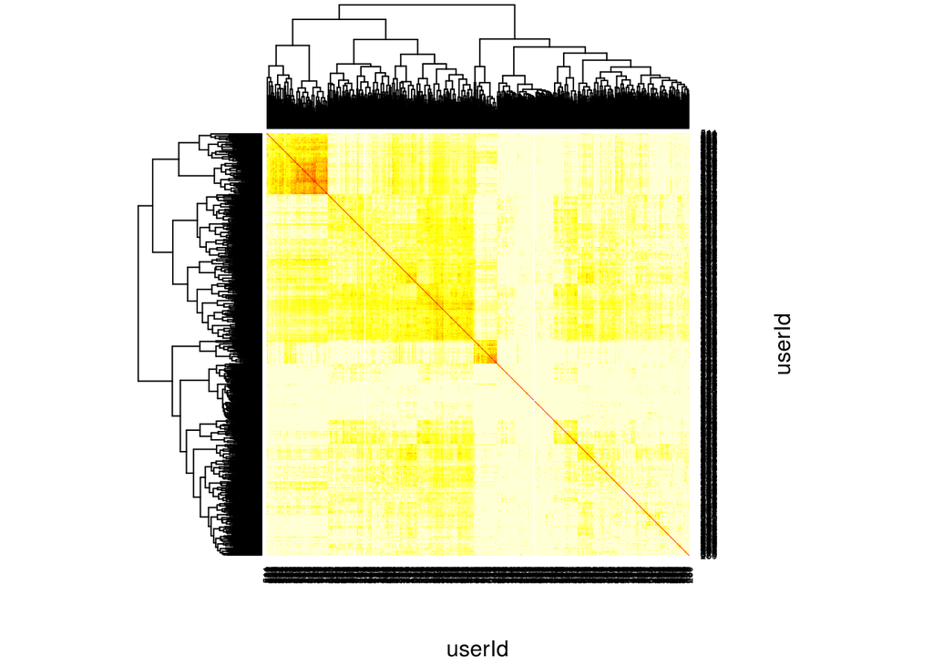

```r
heatmap(as.matrix(1 - correlationMatrix), symm = T, xlab = "userId", ylab = "userId")
```

### Hierarchical clustering

We now perform hierarchical clustering on the dissimilarity matrix `1-correlationMatrix`.

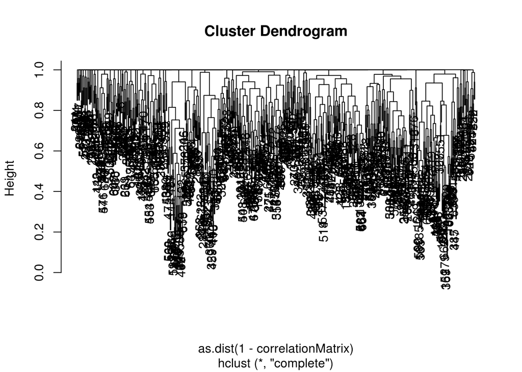

```r
hc <- hclust(as.dist(1 - correlationMatrix))
plot(hc)
```

## Clustering using Principle Component Analysis and the SVD

Next, we perform the SVD on the ratings matrix to obtain the top princple components of the ratings data.

SciDB provides the `gesvd` function in the `dense_linear_algebra` library, for computing the SVD of a dense matrix. To use this function, first load the library.

```r
iquery(dbConnect, "load_library('dense_linear_algebra')")
```

Next, we center the data at 0, a requirement of the PCA.

```r
query_userSum <- "aggregate(ratings_matrix, avg(rating), movieID)"
query_crossjoin <- sprintf("cross_join(ratings_matrix as A, %s as B, A.movieID, B.movieID)",
                           query_userSum)
query_center <- sprintf("project(apply(%s, rating_centered, rating-rating_avg), rating_centered)",
                        query_crossjoin)

ratings_matrix_centered <- iquery(dbConnect,
                                  sprintf("store(%s, ratings_matrix_centered)", query_center),
                                  return = T)
```

Now, we are ready to compute the singular values of the ratings matrix.

```r
ratings_singularValues <- iquery(dbConnect,
                                 "store(gesvd(ratings_matrix_centered, 'S'), ratings_singularValues)",
                                 return = T)
save(ratings_singularValues, file="/home/scidb/Project/ratings_singularValues.Rdata")
```

By inspecting the plot of the singular values, we see that the top 3 singular values capture the most variation in the data.

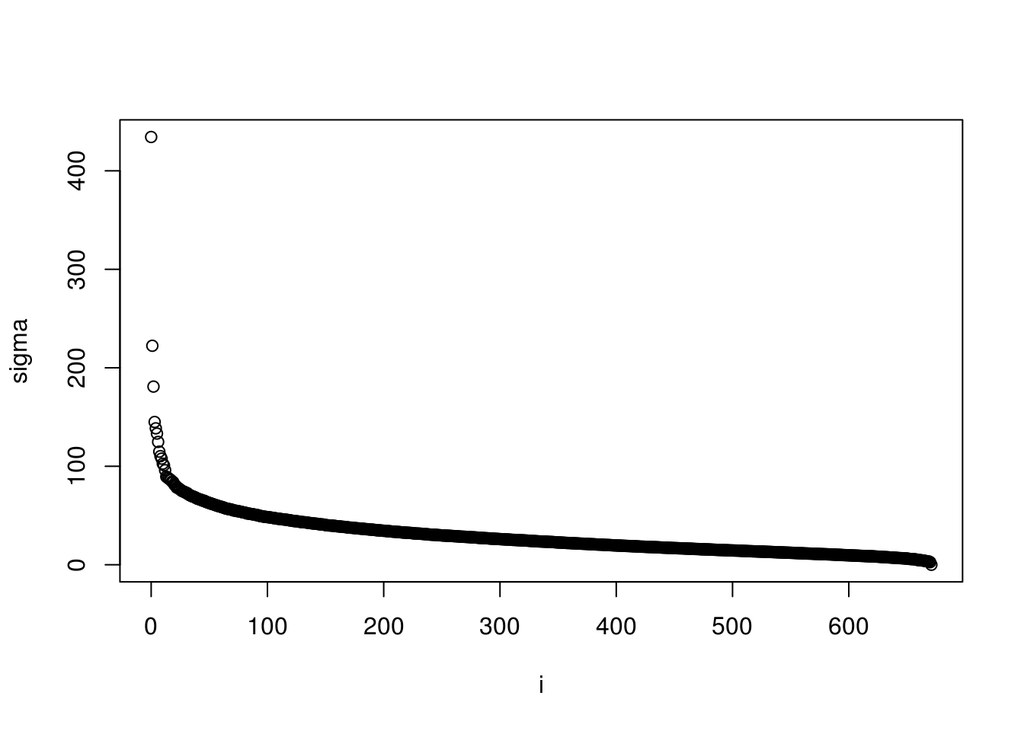

```r
load("/home/scidb/Project/ratings_singularValues.Rdata")

## For logistical reasons, we have saved the SVD results as Rdata format.
## Equivalently, the singular values can be retrieved from the SciDB database
## using the following command:
# ratings_singularValues <- iquery(dbConnect, "filter(ratings_singularValues, TRUE)", return = T)

plot(ratings_singularValues)
```

```r
ratingsSvdU <- iquery(dbConnect, "store(gesvd(ratings_matrix_centered, 'U'), ratingsSvdU)", return = T)
ratingsSvdU[[1]]=as.integer(ratingsSvdU[[1]])
ratingsSvdU[[2]]=as.integer(ratingsSvdU[[2]])
save(ratingsSvdU,file="/home/scidb/Project/ratingsSvdU.Rdata")

ratingsSvdVt <- iquery(dbConnect, "store(gesvd(ratings_matrix_centered, 'VT'), ratingsSvdVt)", return = T)
save(ratingsSvdVt,file="/home/scidb/Project/ratingsSvdVt.Rdata")
```

```r
query <- "apply(apply(ratings_singularValues, i_2, i_1-1), j, i_2)"  # Please check if i or i_1 is the dimension name, and whether it starts at 0 or 1?
query <- sprintf("redimension(%s, <sigma:double>[i_2=0:671,?,0,j=0:671,?,0])", query)
iquery(dbConnect, sprintf("store(%s, ratingsSvdSdiag)", query))
iquery(dbConnect, "store(spgemm(ratingsSvdU, ratingsSvdSdiag), ratingsSvdUxS)")
```

```r
load("/home/scidb/Project/ratingsSvdU.Rdata")

uMat <- spMatrix(nrow = 672, ncol = 672,
                 i = ratingsSvdU$userId + 1,
                 j = ratingsSvdU$i + 1,
                 x = ratingsSvdU$u)
sigMat <- Diagonal(x = c(0,ratings_singularValues$sigma))
# The +1 is due to difference in 0-indexing in SciDB and 1-indexing in R

PCcoords <- uMat * sigMat[1:(nrow(sigMat)-1), 1:(nrow(sigMat)-1)]

# ratings_U10 <- iquery(dbConnect, "subarray(ratings_U, null, 0, null, 4)", return = T)
# ratings_VT10 <- iquery(dbConnect, "subarray(ratings_VT, null, 0, null, 4)", return = T)
```

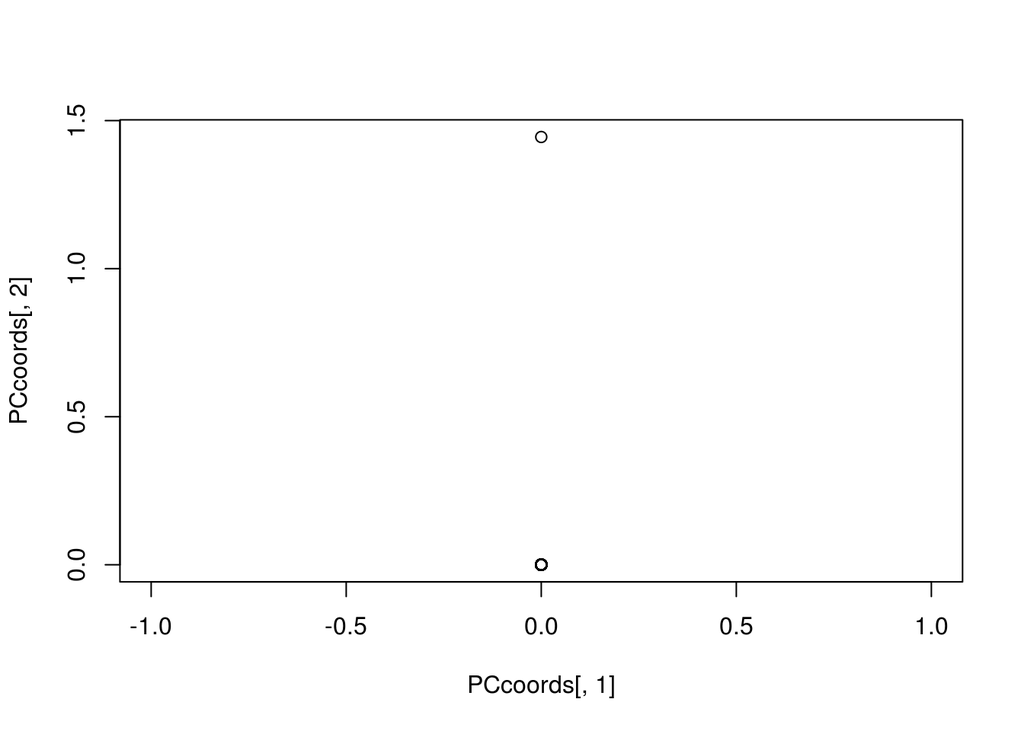

```r
plot(PCcoords[, 1], PCcoords[, 2])
```

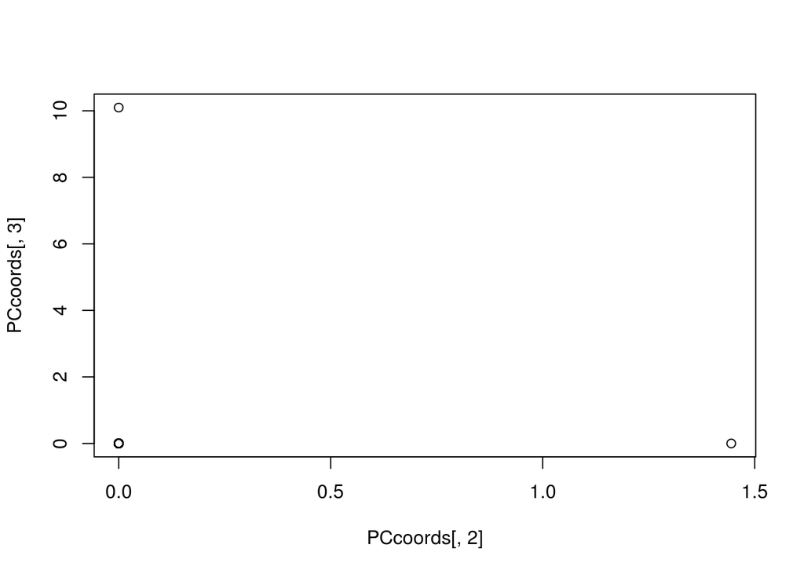

```r
plot(PCcoords[, 2], PCcoords[, 3])
```

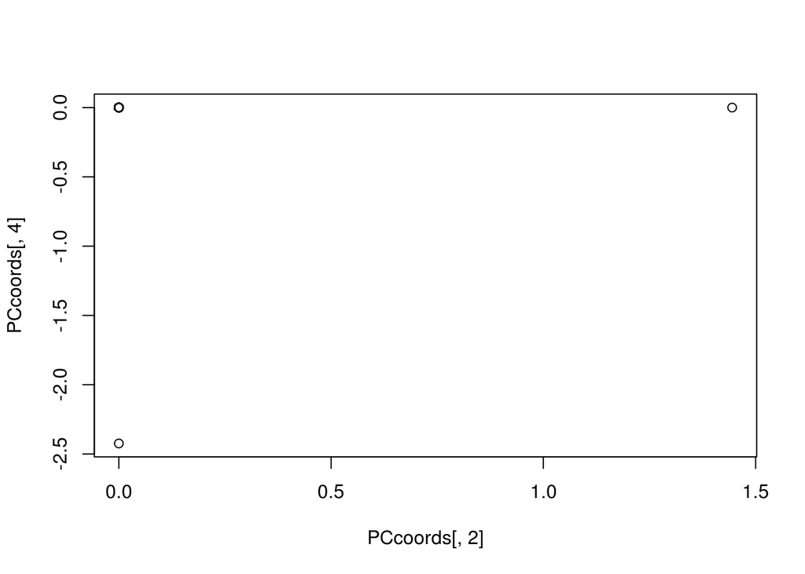

```r
plot(PCcoords[, 2], PCcoords[, 4])
```

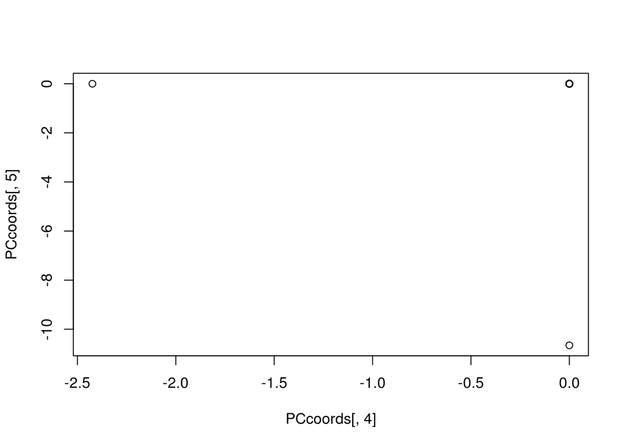

```r
plot(PCcoords[, 4], PCcoords[, 5])
```

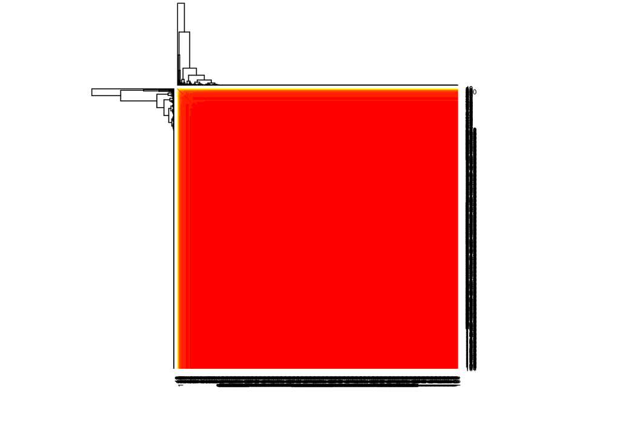

```r
d <- dist(PCcoords[, 1:100])
heatmap(as.matrix(d), symm = T)
```

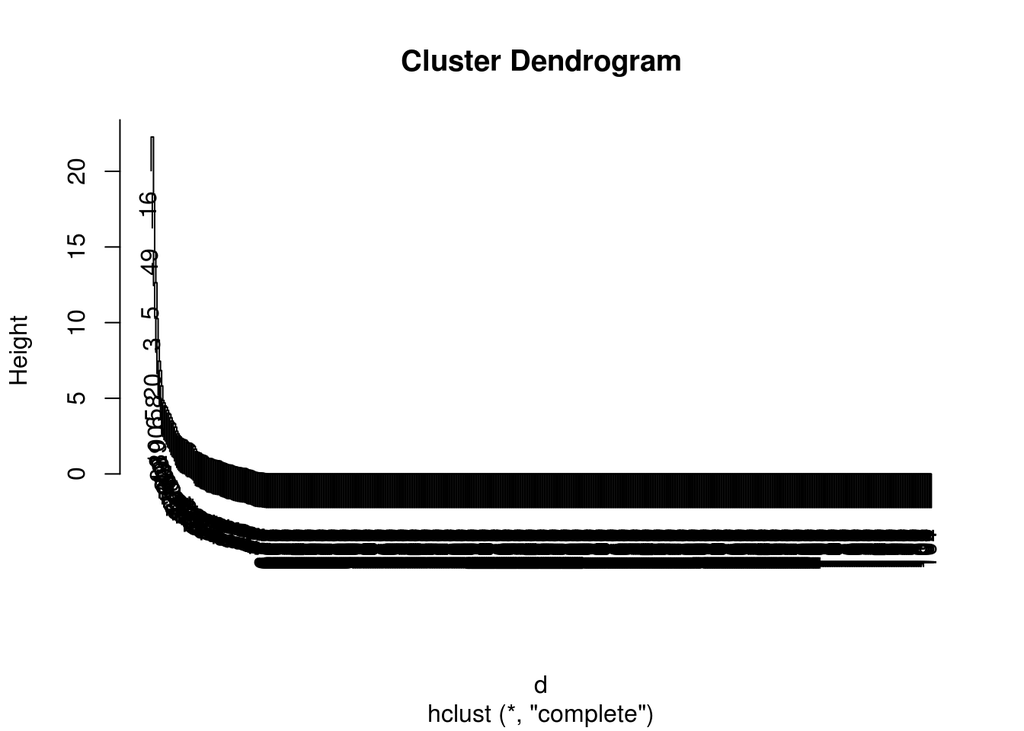

```r
hclustTree <- hclust(d)
plot(hclustTree)
```

# Big Data Computations with the Full Dataset

The computations in the previous section extend to using the full dataset. However, due to limited RAM and hard disk space on our laptops, we are unable to run the identical computations for the full dataset.

We can still show a tractable example: finding the pairwise correlations between movies.

```r
system.time(
  iquery(dbConnect,
         "store(spgemm(transpose(RATINGS_MATRIX), RATINGS_MATRIX), RATINGS_MATRIX_MxMT)")
)
```

[output not shown]